# himac

```python
import numpy as np
mc2 = 940 # MeV
c = 3.0e8 # [m/s]
def gamma(T): # T [MeV]
  return 1 + T/mc2
def beta(T):
  return np.sqrt(gamma(T)**2-1)/gamma(T)

# def t_arrive(theta, theta0, v, V, L):
#   # theta0 = 15/360*2*np.pi # 15 deg.
#   # L = 3.6 # [m]
#   # V = beta(290)*c # [m/s]
#   return L*((1-np.tan(theta0)/np.tan(theta))*np.cos(theta0)/V + np.sin(theta0)/np.sin(theta)/v)*1e9

def t_arrive(theta, theta0, v, V, L):
  return (L*np.cos(theta0)/V + (1/(v*np.cos(theta)) - 1/V)*L*np.sin(theta0)/np.tan(theta)) * 1e9

# beta(290)
# print(t_arrive(np.pi/6,np.pi/12, beta(100)*c, beta(290)*c, 3.6))
# print(t(np.pi/6,np.pi/12, beta(100)*c, beta(290)*c, 3.6))
```

```
1.5707963267948966 0.2617993877991494
```

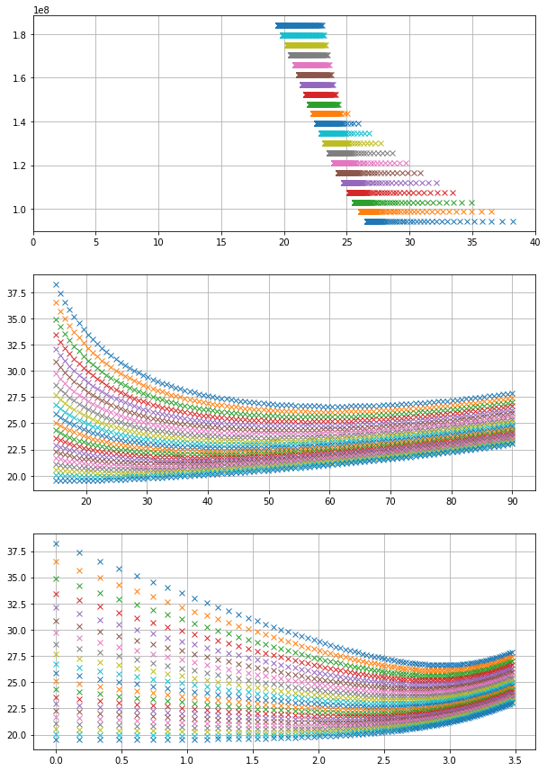

```python
import matplotlib.pyplot as plt

t_list = []
v_list = np.linspace(beta(50)*c,beta(250)*c, num=21)

theta0 = 15/360*2*np.pi
L = 3.6
V = beta(290)*c

theta_list = np.linspace(theta0, np.pi*1/2, num=100)
# theta_list = [ np.arctan(L*np.sin(theta0)/x) for x in np.linspace(0,L*np.cos(theta0))]
print(theta_list[-1], theta0)
for v in v_list:
  t = []
  for theta in theta_list:
    t.append(t_arrive(theta,theta0,v,V,L))

  t_list.append(t)

fig, axes = plt.subplots(3,1,figsize=(10,15))
for i, t in enumerate(t_list):
  axes[0].plot(t,[v_list[i]]*len(t), linestyle='', marker='x')
  axes[1].plot(theta_list*180/np.pi, t, linestyle='', marker='x')
  axes[2].plot(L*np.sin(theta0)/np.tan(theta0)-L*np.sin(theta0)/np.tan(np.array(theta_list)), t, linestyle='', marker='x')

axes[0].set_xlim(0,40)
axes[0].grid(True)

axes[1].grid(True)
axes[2].grid(True)
```

```
0.5235987755982988 0.5235987755982988
```

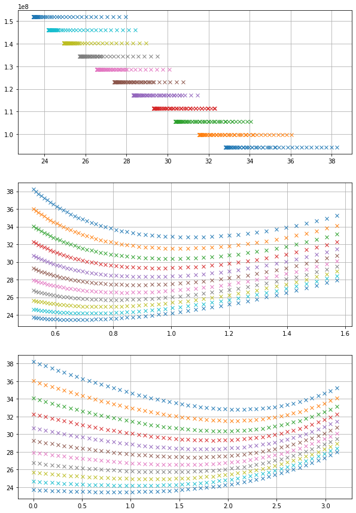

```python
import matplotlib.pyplot as plt

t_list = []
v_list = np.linspace(beta(50)*c,beta(150)*c, num=11)

theta0 = 30/360*2*np.pi
L = 3.6
V = beta(290)*c

# theta_list = np.linspace(theta0, np.pi/2, num=10)
theta_list = [ np.arctan(L*np.sin(theta0)/x) for x in np.linspace(0,L*np.cos(theta0))]
print(theta_list[-1], theta0)
for v in v_list:
  t = []
  for theta in theta_list:
    t.append(t_arrive(theta,theta0,v,V,L))

  t_list.append(t)

fig, axes = plt.subplots(3,1,figsize=(10,15))
for i, t in enumerate(t_list):
  axes[0].plot(t,[v_list[i]]*len(t), linestyle='', marker='x')
  axes[1].plot(theta_list, t, linestyle='', marker='x')
  axes[2].plot(L*np.sin(theta0)/np.tan(theta0)-L*np.sin(theta0)/np.tan(np.array(theta_list)), t, linestyle='', marker='x')

# axes[0].set_xlim(0,4e-8)
axes[0].grid(True)

axes[1].grid(True)
axes[2].grid(True)
```

```
0.7853981633974482 0.7853981633974483
```

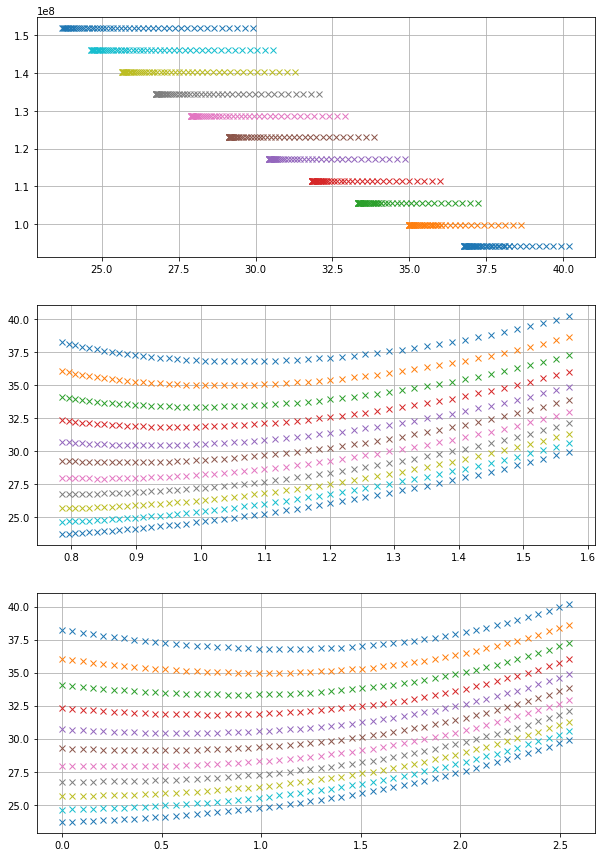

```python
import matplotlib.pyplot as plt

t_list = []
v_list = np.linspace(beta(50)*c,beta(150)*c, num=11)

theta0 = 45/360*2*np.pi
L = 3.6
V = beta(290)*c

# theta_list = np.linspace(theta0, np.pi/2, num=10)
theta_list = [ np.arctan(L*np.sin(theta0)/x) for x in np.linspace(0,L*np.cos(theta0))]
print(theta_list[-1], theta0)
for v in v_list:
  t = []
  for theta in theta_list:
    t.append(t_arrive(theta,theta0,v,V,L))

  t_list.append(t)

fig, axes = plt.subplots(3,1,figsize=(10,15))
for i, t in enumerate(t_list):
  axes[0].plot(t,[v_list[i]]*len(t), linestyle='', marker='x')
  axes[1].plot(theta_list, t, linestyle='', marker='x')
  axes[2].plot(L*np.sin(theta0)/np.tan(theta0)-L*np.sin(theta0)/np.tan(np.array(theta_list)), t, linestyle='', marker='x')

# axes[0].set_xlim(0,4e-8)
axes[0].grid(True)

axes[1].grid(True)
axes[2].grid(True)
```

- 空気と反応する場所がtargetから遠いほど、見込む検出器の立体角は大きくなる。
- vetoに引っかからない立体角も大きくなる。
- エネルギー損失によりbeamの速度が落ちることで、targetから遠いほど到達するまでの時間が増加する？どのくらいのエネルギー損失があるか調べる必要あり。
- 30, 45度のバックグラウンドについては15度のシャドーバーにより、ビームが空気と反応してできる陽子を遮蔽してしまうため、foregroundの時にはある空気からの陽子の寄与を取り除けていない。
- 陽子のエネルギーは放出角度によって一意に決まるのか？
- small検出器では不自然な山が見られないのはvetoによって切られているためだと考えられる。
- small用に置いたシャドーバーのせいでバックグラウンドを過小評価している可能性
- 空気とビームの反応が無視できないほど大きそう。
- 空気中の陽子の飛程は？
- targetからの粒子と空気からの粒子の量の比で山の大きさが変わる？ビームが同じだと、targetで通過する原子の数が大きいほど山が小さくなっている？核子の数で比較すべき？

```
0.26179938779914935 0.2617993877991494
```

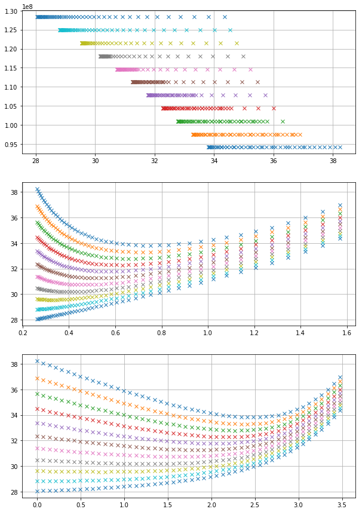

```python
import matplotlib.pyplot as plt

t_list = []
v_list = np.linspace(beta(50)*c,beta(100)*c, num=11)

theta0 = 15/360*2*np.pi
L = 3.6
V = beta(100)*c

# theta_list = np.linspace(theta0, np.pi/2, num=10)
theta_list = [ np.arctan(L*np.sin(theta0)/x) for x in np.linspace(0,L*np.cos(theta0))]
print(theta_list[-1], theta0)
for v in v_list:
  t = []
  for theta in theta_list:
    t.append(t_arrive(theta,theta0,v,V,L))

  t_list.append(t)

fig, axes = plt.subplots(3,1,figsize=(10,15))
for i, t in enumerate(t_list):
  axes[0].plot(t,[v_list[i]]*len(t), linestyle='', marker='x')
  axes[1].plot(theta_list, t, linestyle='', marker='x')
  axes[2].plot(L*np.sin(theta0)/np.tan(theta0)-L*np.sin(theta0)/np.tan(np.array(theta_list)), t, linestyle='', marker='x')

# axes[0].set_xlim(0,4e-8)
axes[0].grid(True)

axes[1].grid(True)
axes[2].grid(True)
```

```python
print(beta(290))
print(beta(100))
print(np.arcsin(beta(100)/beta(290))/np.pi*180)

for T in np.linspace(0,150,16):
  print(T, np.arcsin(beta(T)/beta(290))/np.pi*180)
```

```
0.6449465952934553
0.4278576050247499
41.55969853081991
0.0 0.0
10.0 12.966404355407754
20.0 18.35145728388571
30.0 22.496839583829495
40.0 26.005715810517096
50.0 29.112401325802466
60.0 31.937672247926862
70.0 34.55383803138297
80.0 37.00855880156382
90.0 39.33548856884265
100.0 41.55969853081991
110.0 43.70071749339314
120.0 45.77437008406938
130.0 47.79396317860999
140.0 49.771101556143634
150.0 51.71628850322328
```

```python
import numpy as np
def theta2z(theta, theta0, L):
  h = L*np.sin(theta0)
  # print(np.tan(theta0), np.tan(theta))
  z =  h*(1/np.tan(theta0) - 1/np.tan(theta))

  return z

print(theta2z(np.pi*3/4, np.pi/12, 3))
```

```
3.6742346141747673
```

```python
def dzdtheta(theta, theta0, L):
  h = L*np.sin(theta0)

  return h/(np.tan(theta)**2*np.cos(theta)**2)
```

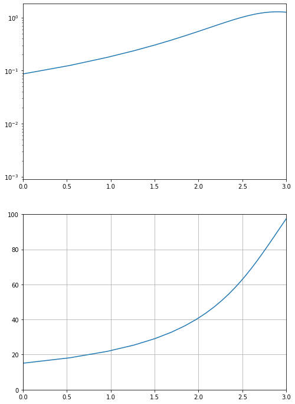

```python
import matplotlib.pyplot as plt

fig, ax = plt.subplots(2,1,figsize=(8,12))

theta0 = np.pi/12
L = 3

theta = np.linspace(0, np.pi*0.99)
ax[0].plot(theta2z(theta, theta0, L), 1/dzdtheta(theta, theta0, L))
ax[0].set_yscale('log')
ax[0].set_xlim(0,3)

ax[1].plot(theta2z(theta, theta0, L), theta*180/np.pi)
ax[1].set_xlim(0, 3)
ax[1].set_ylim(0, 100)
ax[1].grid(True)
```

# ある陽子のエネルギーについて、到達時間スペクトルを計算する

1. $f(\theta, E_p)\mathrm{d\theta} = P(\theta, E_p)\rho \mathrm{dz} \\ f(\theta,E_p) = P(\theta,E_p)\rho \frac{\mathrm{dz}}{\mathrm{d\theta}}$
2. $f(t,E_p)\mathrm{dt} = \int_{\theta_0}^{\theta_{max}}f(\theta, E_p)\mathrm{d\theta}$ if $t \le t(\theta) \le t+\mathrm{dt}$
3. f[i_t] += f(bins_theta[i_theta], E_p)*delta_theta/delta_t, bins_t[i_t] <= t(bins_theta[i_theta]) < bins_t[i_t+1]

# 1

```python
theta0 = np.pi/12
rho = 1
L = 3.6
E_beam = 290 # MeV/u
mc2 = 940 # MeV
c = 3.0e8 # [m/s]


def dzdtheta(theta):
  h = L*np.sin(theta0)

  # return h/(np.tan(theta)**2*np.cos(theta)**2)
  return h/np.sin(theta)**2

def gamma(E): # E [MeV/u]
  return 1 + E/mc2
def beta(E):
  return np.sqrt(gamma(E)**2-1)/gamma(E)

def P(theta, Ep):
  # phitsの計算結果から
  # return 1

  # 目分量
  return np.exp(-3/((120/180)*np.pi)*theta)*(theta > np.pi/6) + np.exp(-3/((120/180)*np.pi)*np.pi/6)*(theta <= np.pi/6) # だいたいの式 Ep = 50

def f_theta(theta, Ep):
  return P(theta, Ep)*rho*dzdtheta(theta)

def t(theta, Ep): # nsec
  V = c*beta(E_beam)
  v = c*beta(Ep)
  return (L*np.cos(theta0)/V + (1/(v*np.cos(theta)) - 1/V)*L*np.sin(theta0)/np.tan(theta)) * 1e9
```

# 2

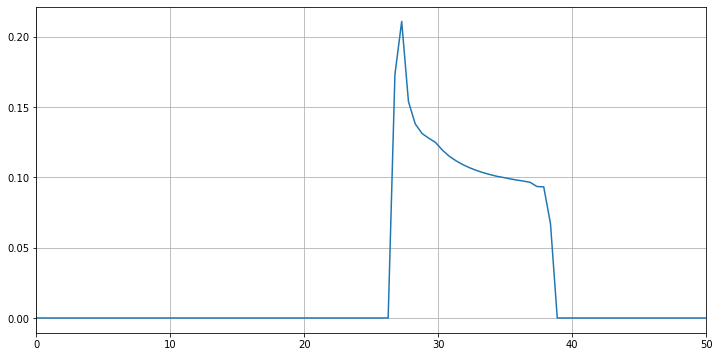

```python
import bisect

Ep = 50 # MeV
bins_theta = np.linspace(theta0, np.pi*3/4, num=100000)
bins_t = np.linspace(0, 50, num=100)
# print(bins_t)
delta_theta = bins_theta[1] - bins_theta[0]
delta_t = bins_t[1] - bins_t[0]


f_t = np.zeros(bins_t.shape)

for theta in bins_theta:
  # print(bins_t)
  # print(t(theta,Ep))
  i_t = bisect.bisect_left(bins_t, t(theta, Ep))
  # print(i_t)
  if i_t == len(f_t):
    continue
  f_t[i_t] += f_theta(theta, Ep)*delta_theta/delta_t


import matplotlib.pyplot as plt

fig, ax = plt.subplots(1,1, figsize=(12,6))

ax.plot(bins_t, f_t)
# ax.set_ylim(0,1.1)
ax.set_xlim(0,50)
ax.grid(True)
```